# ECON 57: Economic Statistics - R Notebook

# Reading and Writing Files in R

In this section, we will explore how to read and write various types of files in R, including CSV and Excel files, which are commonly used in economic data analysis.

## Reading CSV Files

To read a CSV file in R, we can use the read.csv() function. Let’s assume we have a CSV file named “economic_data.csv” containing economic data.

```r
# Reading a CSV file
data <- read.csv(file.choose())
data
```

## Writing CSV Files

To write a data frame to a CSV file, we can use the write.csv() function.

```r
# Writing a data frame to a CSV file
write.csv(new_data, "updated_economic_data.csv", row.names = FALSE)
```

## Reading Excel Files

To read an Excel file in R, we need the readxl package. Install it using install.packages(“readxl”) if not already installed.

```r
# install.packages("readxl")
# Load the readxl package
library(readxl)

# Reading an Excel file
economic_data_excel <- read_excel(file.choose(), sheet = "Sheet1")
```

## Writing Excel Files

To write a data frame to an Excel file, we can use the openxlsx package. Install it using install.packages(“openxlsx”) if not already installed.

```r
# install.packages("openxlsx")
# Load the openxlsx package
library(openxlsx)

# Create a new Excel workbook
wb <- createWorkbook()

# Add a data frame to the workbook
addWorksheet(wb, "EconomicData")
writeData(wb, "EconomicData", economic_data)

# Save the workbook
saveWorkbook(wb, "economic_data_updated.xlsx")
```

**Exercise:** Download some economic data from a reputable source as a CSV file into your computer. Then, read the CSV file and print the data. Compute summary/descriptive statistics. Finally, write the data to an Excel file with appropriate formatting

# Two-way Entry Table in R

In economic analysis, two-way tables (also known as contingency tables) are used to display the frequency distribution of two categorical variables.

## Creating Two-way Tables

Let’s consider a scenario where we have surveyed individuals regarding their employment status and education level.

```r
# Create a data frame
survey_data <- data.frame(
  Employment = c("Employed", "Unemployed", "Employed", "Unemployed", "Employed"),
  Education = c("High School", "College", "College", "High School", "Graduate")
)

# Create a two-way table
table_data <- table(survey_data$Employment, survey_data$Education)
print(table_data)
```

```
             College Graduate High School
  Employed         1        1           1
  Unemployed       1        0           1
```

## Visualizing Two-way Tables

We can create a bar plot to visualize the two-way table using the barplot() function.

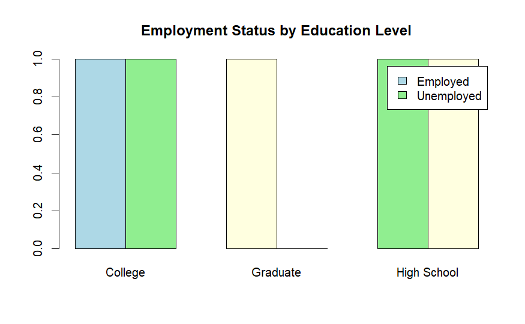

**Exercise:** Create a two-way table and a stacked bar plot to analyze the relationship between transportation mode (car, bike, walk) and income level (low, medium, high) based on survey data.

# Covariance and Correlation in R

Covariance and correlation are essential concepts in statistics that help us understand the relationship between two continuous variables.

## Calculating Covariance

Covariance measures the degree to which two variables change together.

```r
# Sample data: Quarterly GDP and Unemployment Rate
GDP <- c(1200, 1300, 1350, 1400, 1500)
UnemploymentRate <- c(5.2, 5.0, 4.8, 4.5, 4.2)

# Calculate means
mean_GDP <- mean(GDP)
mean_UnemploymentRate <- mean(UnemploymentRate)

# Calculate covariance using the formula
n <- length(GDP)
covariance <- sum((GDP - mean_GDP) * (UnemploymentRate - mean_UnemploymentRate)) / (n - 1)
print(covariance)
```

```
[1] -43.75
```

```r
# But R makes it real easy to do this
covariance <- cov(GDP, UnemploymentRate)
print(covariance)
```

```
[1] -43.75
```

```r
# todo: download csv file with economic data
economic_data <- read.csv(file.choose())

# Calculate covariance between GDP and Unemployment Rate
covariance <- cov(economic_data$GDP, economic_data$UnemploymentRate)
print(covariance)
```

## Calculating Correlation

Correlation quantifies the strength and direction of the linear relationship between two variables.

```r
# Calculate standard deviations
sd_GDP <- sd(GDP)
sd_UnemploymentRate <- sd(UnemploymentRate)

# Calculate correlation using the formula
correlation <- covariance / (sd_GDP * sd_UnemploymentRate)
print(correlation)
```

```
[1] -0.9844519
```

```r
# Calculate correlation between GDP and Unemployment Rate
correlation <- cor(GDP, UnemploymentRate)
print(correlation)
```

```
[1] -0.9844519
```

```r
# Calculate correlation between GDP and Unemployment Rate
correlation <- cor(economic_data$GDP, economic_data$UnemploymentRate)
print(correlation)
```

**Exercise:** Initialize two vectors representing data of your liking, compute the covariance and correlation of these vectors.